# Analyzing Cryptocurrency Markets using R - Part 3 Rolling Correlations and More!

Dr. Aous Abdo @aousabdo

In my two previous posts, [Downloading and Processing Crypto Data with R](http://rpubs.com/aousabdo/crypto_1) and [Corrleations in the Crypto World Part 1](http://rpubs.com/aousabdo/crypto_2) I went over how one can download crypto data in R and talked about static correlations for some coins. In this post, we will cover rolling correlatoins, a type of correlations we use with time-series data like crypto data.

## R Libraries

In this post we will be using the same libraries from my previous [post](http://rpubs.com/aousabdo/crypto_2). We will also reuse some of the functions introducec in that post.

## Rolling Correlations

Establishing a relationship, in this case a correlation, between two time series can be very benificial for several reasons, the most important of which is being able to use this relationship to predict market movement, which if you can acheive then you’ll be rich. Established correlations between the price of a crypto currency, for example, with other time series data such as market sentiment, news, or the price of another crypto currency, can be used to better forecast the movement of that coin. But as we have seen in the previous [post](http://rpubs.com/aousabdo/crypto_2), one problem exists, these correlations are not static and they could vary greatly overtime.

Rolling correlations are similar to [moving averages](https://www.investopedia.com/university/movingaverage/movingaverages1.asp), they are metrics we apply over a time window to better see potential trends and avoid the noise in the data. Since this might be a new topic for some readers let’s elaborate more.

Suppose we have a dataset which reflects daily sales for a department store for three products, A, B, and C. The sales for these products are shown in the table below.

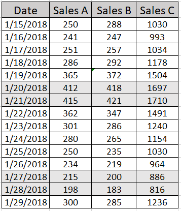

Department store sales

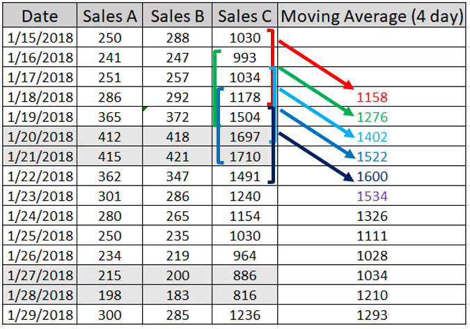

Department store sales moving average

One major factor in a rolling function is the time window over which this function is applied. Intuitively, one would expect the variability in the value returned to be lower for larger time windows. We show that in the figure below where we calcualte the moving averages for different time windows.

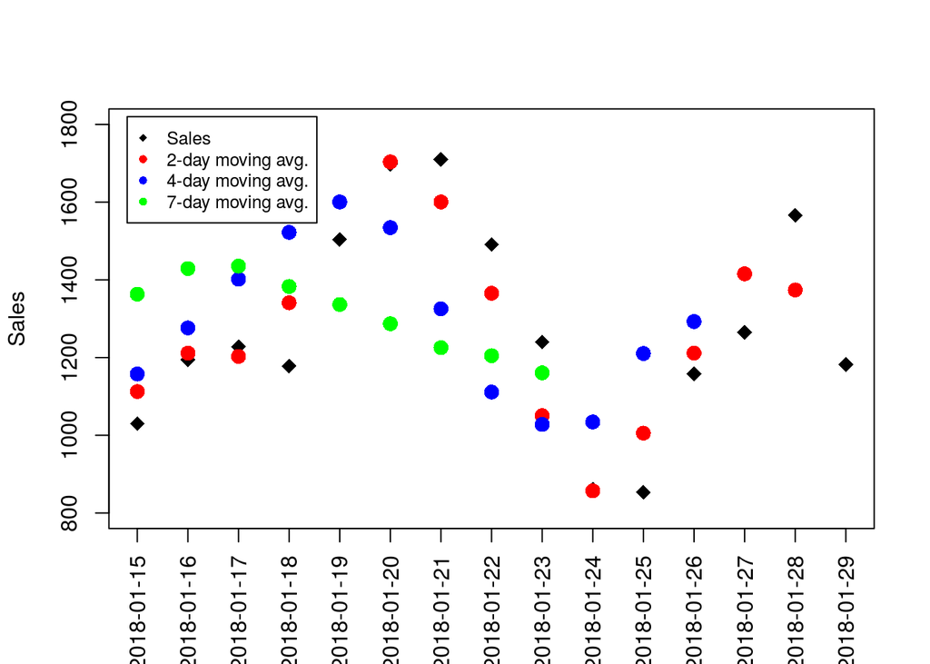

```r
# sales for product C
prod_c <- c(1030, 1195, 1228, 1178, 1504, 1697,1710 ,1491 ,1240 , 861, 853, 1158, 1265, 1566,1182)
dates <- mdy(paste("1", 15:29, "2018", sep = "-"))

# calculate 3 moving averages for time windows of 2, 4, and 7 days
sma2 <- rollmean(prod_c, k = 2)
sma4 <- rollmean(prod_c, k = 4)
sma7 <- rollmean(prod_c, k = 7)

# plot sales and overlay the moving averages
plot(prod_c, pch = 18, col = "black", xlab = "", ylab = "Sales", cex = 1.5, ylim = c(800, 1800), xaxt ="n")
axis(1, at = 1:15, labels = dates, las = 2)
points(sma2, col = "red", pch=16, cex = 1.5)
points(sma4, col = "blue", pch=16, cex = 1.5)
points(sma7, col = "green", pch=16, cex = 1.5)

# add legend
legend(0.8, 1820, legend=c("Sales", "2-day moving avg.", "4-day moving avg.", "7-day moving avg."),
       col=c("black", "red", "blue", "green"),  pch = c(18, rep(16, 3)), cex=0.8)
```

Notice how increasing the time window helps us get rid of the noise in the data. This is evident from the smoother curves for the moving averages with time windows of 4 and 7. It is also worth noting that increasing the time window decreases the number number of retunred moving averages. This implies that a moving average over the whole period will result in just one number, which is simply the average over the whole period.

The same can be done to any function that calculates a static value, like calculating correlations between two time series. Let’s now calculate the rolling correlations over a period of 4 days for the sales of Products A and C.

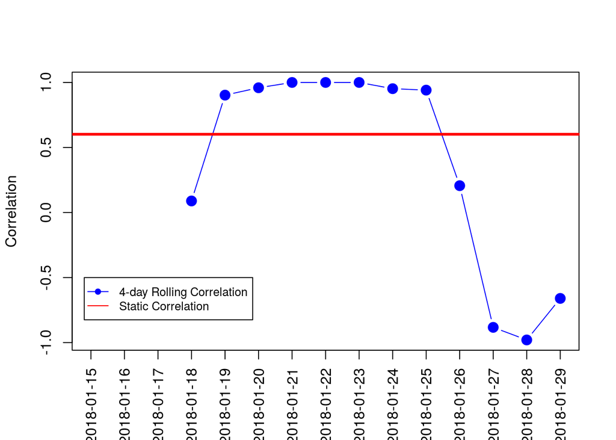

```r
# let's put the two sales of products A and C in a data.frame
prod_a <- c(250, 241, 251, 286, 365, 412, 415, 362, 301, 280, 250, 234, 215, 198, 300)
prod_c <- c(1030, 1195, 1228, 1178, 1504, 1697,1710 ,1491 ,1240 , 861, 853, 1158, 1265, 1566,1182)

df <- data.frame(prod_a, prod_c)

# now we'll calculate the rolling correlation
rollcorr_a_c <- runCor(df[, 1], df[, 2], n = 4)

# now let's make a plot
plot(rollcorr_a_c, pch = 19, col = "blue", xlab = "", ylab = "Correlation", cex = 1.5, type = "b", xaxt = "n")
axis(1, at = 1:15, labels = dates, las = 2)
abline(h = cor(df[, 1], df[2]), col = "red", lwd = 3)
legend(0.8, -0.5, legend=c("4-day Rolling Correlation", "Static Correlation"),
       col=c("blue", "red"),  lty=c(1, 1),pch=c(19, NA), cex=0.8)
```

As one can see from the above figure, for time series the correlation is not static and changes over time. In the figure the rolling correlation, shown in blue, varies greatly overtime, while the static correlation (shown in red) is constant.

A sudden change in rolling correlation can be of great interest as to why it [happened](http://www.business-science.io/timeseries-analysis/2017/07/30/tidy-timeseries-analysis-pt-3.html). In the example above, the sudden decreas in rolling correlation on Juanuary 26th between the sales of the two products can reveal some great insights about what happened on that day that caused this change. We will be be looking for sudden changes in rolling correlations between alt coins and bitcoin and see if there are any sudden shifts/changes in this rolling correlation, and maybe try to answer why that sudden change happened.

### Rolling Correlation for Cryptocurrencies

We will be using the dataset we downloaded in our previous [post](http://rpubs.com/aousabdo/crypto_2). This dataset is shown in the table below.

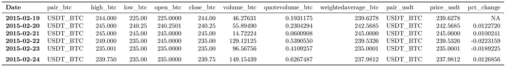

```r
kable(head(alt_data), "latex", booktabs=T) %>% column_spec(1, bold = T) %>% kable_as_image()
```

We will be performing our analysis on the daily returns, so we only need a subset of this dataset:

```r
alt_data_sub <- as.tibble(alt_data)
```

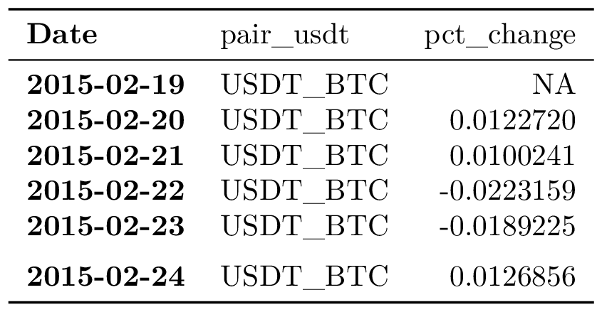

```r
alt_data_sub2 <- alt_data_sub %>%
  select(Date, pair_usdt, pct_change)
alt_data_sub2 %>% head() %>%
kable("latex", booktabs=T) %>% column_spec(1, bold = T) %>% kable_as_image()
```

This table contains three columns, the Date column, the pair_usdt column which is just the name of the coin pair, and the percentage daily change. We will be using this table to calculate the rolling correlations. The rolling correlations we will be calculating is with respect to Bitcoin, that is, we want to explore the rolling correlatoins of each altcoin against bitcoin.

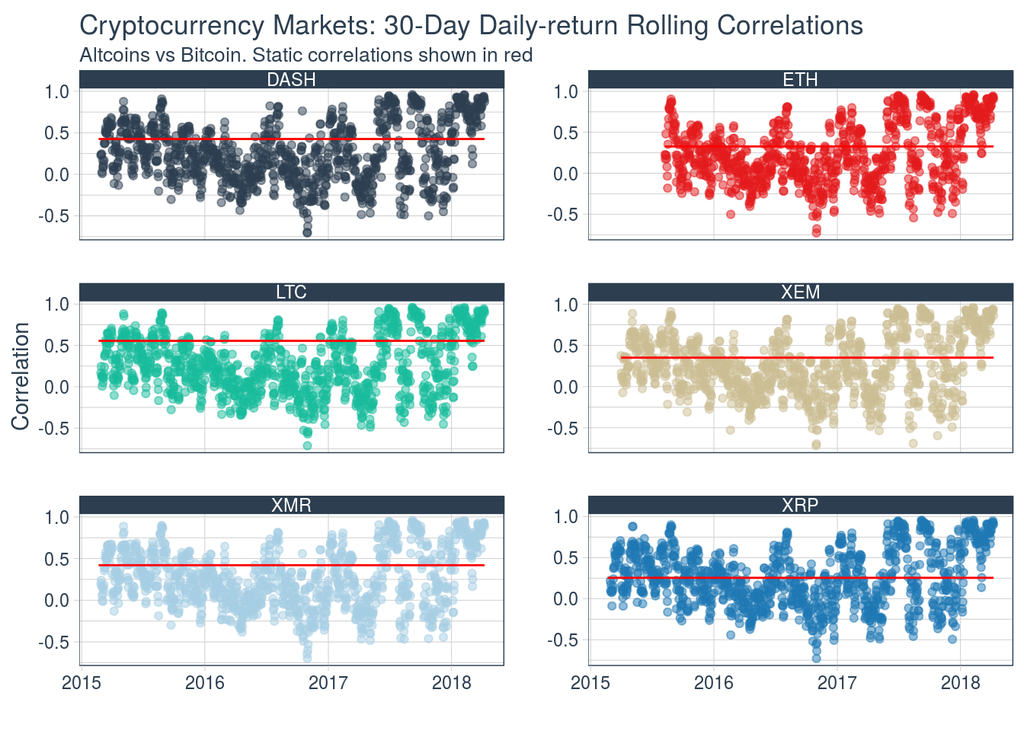

```r
# Since we are calculating the rolling correlations for altcoins against bitcoin, we need to add bitcoin as a new
# column to help with our calculations

# we'll start by only keeping the columns we need
alt_data_sub2 <- alt_data_sub %>%
  select(Date, pair_usdt, pct_change)

# let's create a new tibble with only BTC data. We'll join this table to the other table
btc_data <- alt_data_sub2 %>% filter(pair_usdt == "USDT_BTC")

# This table will only contain the alt coin data
alt_data_sub3 <- alt_data_sub2 %>% filter(pair_usdt != "USDT_BTC")

# clean the names of the coins
alt_data_sub3 <- alt_data_sub3 %>% mutate(pair_usdt = gsub("^USDT_", "", pair_usdt))

# now we'll calculate the static correlations
# calculat static correlations
alt_data_static_corr <- alt_data_sub3 %>%
  spread(key = pair_usdt, value = pct_change) %>%
  left_join(btc_data, by = "Date") %>%
  select(-pair_usdt) %>%
  rename(BTC = pct_change) %>%
  select(-Date) %>%
  correlate()

# now we calculat the rolling correlations using the runCor function
# I got most of this code from this great post:
# http://www.business-science.io/timeseries-analysis/2017/07/30/tidy-timeseries-analysis-pt-3.html

alt_data_roll_corr <- alt_data_sub3 %>%
  left_join(btc_data, by = "Date") %>%
  drop_na() %>%
  tq_mutate_xy(
    x          = pct_change.x,
    y          = pct_change.y,
    mutate_fun = runCor,
    # runCor args
    n          = 30, # number of days to calculate the rolling correlation
    use        = "pairwise.complete.obs",
    # tq_mutate args
    col_rename = "rolling_corr"
  )

# lets do some cleaning for the rolling correlation data frame
alt_data_roll_corr <- alt_data_roll_corr %>% rename(Coin = pair_usdt.x
                                                    , BTC = pair_usdt.y
                                                    , pct_change_coin = pct_change.x
                                                    , pct_change_BTC = pct_change.y) %>%
  mutate(Coin = gsub("^USDT_", "", Coin), BTC = gsub("^USDT_", "", BTC))

# we will now need to join the two correlation tables
alt_data_static_corr <- alt_data_static_corr %>%
  select(rowname, BTC) %>%
  rename(Coin = rowname)

alt_data_roll_corr <- alt_data_roll_corr %>% left_join(alt_data_static_corr, by = "Coin") %>%
  rename(static_corr = BTC.y)

# make the plot
alt_data_roll_corr %>%
  select(Date, Coin, static_corr, rolling_corr) %>%
  ggplot(aes(x = Date, color = Coin)) +
  # Data
  geom_point(aes(y = rolling_corr), alpha = 0.5) +
  geom_line(aes(y = static_corr), color = "red") +
  facet_wrap(~ Coin, ncol = 2, scales = "free_y") +
  # Aesthetics
  scale_color_tq() +
  labs(
    title = "Cryptocurrency Markets: 30-Day Daily-return Rolling Correlations",
    subtitle = "Altcoins vs Bitcoin. Static correlations shown in red",
    x = "", y = "Correlation"
  ) +
  theme_tq() +
  theme(legend.position="none")
```

We can clearly see significant changes in the rolling correlation itself over this rolling window. what is also apparent are the similarities between the rolling correlations for the different altcoins. Let’s look at a larger time window, say 90 days. The larger time window will allow us to better see any potential patterns in the data. I did exclude “BCH” from the figure since it only goes back to the Fall of 2017. I will also be fitting a LOESS model with a span of 0.05 to capture the high fluctuations we see in the data (I basically added this line to the code snippet above `geom_smooth(method="loess", se=FALSE, size=0.5, span = 0.05)` as well as adjusting n to 90).

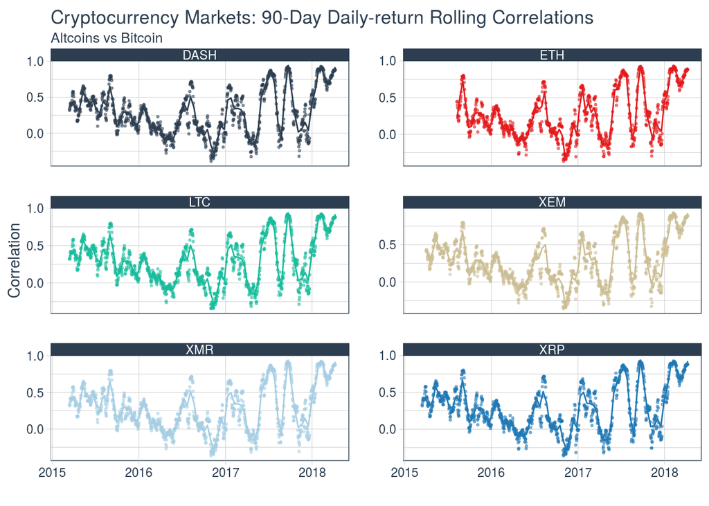

The above figure shows some significagnt and interesting patters in the rolling correlations of the daily return for all alt coins in consideration. What is also interesting is the fact that these patters are very similar.

Next we will find the dates at which the local minima and maxima for the rolling correlations occur. Since the trends are very similar for all alt coins we are analyzing, we will be doing this for only one alt coin, XRP.

```r
# in this secion we will build an algorithm that will detect local minima and maxima in
# time series data

# original code taken from https://rpubs.com/mengxu/peak_detection with some modifications
argmax <- function(x, y, w=1, FUN = max, ...) {
  require(zoo)
  n <- length(y)
  y.smooth <- loess(y ~ x, ...)$fitted
  y.peak <- rollapply(data = zoo(y.smooth), width = 2*w+1, FUN = FUN, align = "center")
  delta <- y.peak - y.smooth[-c(1:w, n+1-1:w)]
  if(FUN == "max")
    i.max <- which(delta <= 0) + w
  else if(FUN == "min")
    i.max <- which(delta >= 0) + w
  list(x = x[i.max], i = i.max, y.hat = y.smooth)
}

findMinMax <- function(x, y, x_axis_time = TRUE, w, span) {
  if(x_axis_time) x2 <- seq_along(x)
  minima <- argmax(x2, y, w=w, span=span, FUN = "min")
  maxima <- argmax(x2, y, w=w, span=span, FUN = "max")

  plot(x, y, cex=0.75, col="Gray", xlab = "Date", ylab = "Rolling Correlation")
  lines(x, minima$y.hat,  lwd=2)
  y.min <- min(y)

  sapply(minima$i, function(i) lines(c(x[i],x[i]), c(y.min, minima$y.hat[i]), col="Red", lty=2))
  points(x[minima$i], minima$y.hat[minima$i], col="Red", pch=19, cex=1.25)

  sapply(maxima$i, function(i) lines(c(x[i],x[i]), c(y.min, maxima$y.hat[i]), col="blue", lty=2))
  points(x[maxima$i], maxima$y.hat[maxima$i], col="blue", pch=19, cex=1.25)

  legend("top", legend=c("Local Minima", "Local Maxima"),
         col=c("red", "blue"),  pch = c(19, 19), cex=0.8)

  df <- data.frame(x_value = c(x[minima$i], x[maxima$i])
                   , y_value = c(minima$y.hat[minima$i], maxima$y.hat[maxima$i])
                   , minmax = as.factor(c(rep("minima", length(x[minima$i])), rep("maxima", length(x[maxima$i])))))
  df <- df %>% arrange(x_value)
  return(df)
}
```

```r
XRP_data <- alt_data_roll_corr %>%
  select(Date, rolling_corr, Coin) %>%
  filter(Coin == "XRP")

# remove NAs
XRP_data <- XRP_data %>% filter(!is.na(rolling_corr))

XRP_corr <- XRP_data$rolling_corr

corr_min_max <- findMinMax(x = XRP_data$Date, y = XRP_corr, x_axis_time = TRUE, w = 40, span = 0.05)
```

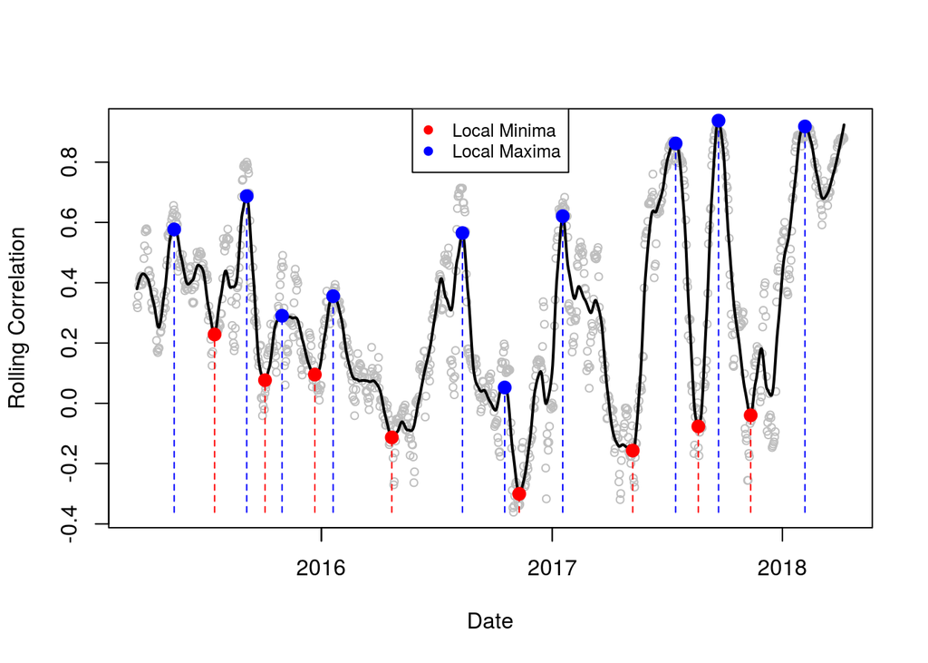

The figure above shows rolling correlations of XRP with the maxima and minima detected using our code above. One can see that the swings in the rolling correlation seem to get more significant with time, i.e. differences between the local minima and maxima appear to increase with time.

Our algorithm detected 18 points of local minima and maxima. The dates at which the maxima and minima occur are:

```r
corr_min_max$x_value
```

```
##  [1] "2015-05-12 17:00:00 PDT" "2015-07-15 17:00:00 PDT"
##  [3] "2015-09-04 17:00:00 PDT" "2015-10-03 17:00:00 PDT"
##  [5] "2015-10-30 17:00:00 PDT" "2015-12-21 16:00:00 PST"
##  [7] "2016-01-19 16:00:00 PST" "2016-04-21 17:00:00 PDT"
##  [9] "2016-08-11 17:00:00 PDT" "2016-10-17 17:00:00 PDT"
## [11] "2016-11-09 16:00:00 PST" "2017-01-17 16:00:00 PST"
## [13] "2017-05-08 17:00:00 PDT" "2017-07-15 17:00:00 PDT"
## [15] "2017-08-20 17:00:00 PDT" "2017-09-21 17:00:00 PDT"
## [17] "2017-11-11 16:00:00 PST" "2018-02-05 16:00:00 PST"
```

If we just look at data after 2016 we see a major uptrend with a local maxima around Jaunury 17, 2017, this was followed by a major downtrend with a local minima in May of 2017. Then we saw another major uptrend two months later in July of 2017, followed by a sharp downtrend a month later in August. Less than a month after that we saw the global maxima in September followd by another sharp downturn in November.

I really have no clue what is causing these major swings in the rolling correlation between altcoins and bitcoin, but I have a feeling it has to do with the following:

1. News and market sentiment
2. Price of bitcoin itself

We will be investigating these dates further in our coming posts.